# Private Federated Aggregation of LLM-Agent Memory

### Usable Shared Memory with a Measurable Leakage-Drop Guarantee under Secure Aggregation and the Skellam Mechanism

## Abstract

LLM agents increasingly accumulate **per-user memory**, distilled notes, preferences, and skill embeddings (as in A-MEM and Mem0), that make them personal and effective. Pooling these memories *across users* would let a fleet of agents share hard-won knowledge, but the memory objects are exactly the sensitive artifact: recent extraction (MEXTRA) and membership-inference (MRMMIA) attacks recover verbatim user facts from agent memory. We ask whether a shared memory pool can be made **useful and provably private at once**.

We aggregate per-user memory-note embeddings into a shared, bucketed **centroid memory** under **Secure Aggregation (SecAgg)** composed with the **discrete Skellam mechanism**, so the pooled memory carries a single central differential-privacy guarantee with **no trusted curator** and **no individual note in the clear**. The payload is new but the cryptographic path is verbatim prior work, which lets us reuse a rigorous discrete-DP accountant. We evaluate on **LongMemEval** (real long-horizon conversational memory) and on **LLM-distilled A-MEM/Mem0-style notes**, along two axes: (i) **retrieval utility** of the noised pool, and (ii) the **drop in worst-case re-identification** of vulnerable members.

**(1) Usable DP memory.** In the regime where agent payloads actually live, **tiny embedding dimension and coarse bucketing**, the private pool retains **95–96% of clean retrieval utility at ε≈9.3** on real data.

**(3) The dimension/density crossover governs both axes at once.** Higher embedding dimension *simultaneously* increases pre-DP leakage and decreases DP utility-retention, so **tiny-d is Pareto-preferred**, precisely where Skellam's low-precision advantage compounds. We further show the discrete mechanism is **privacy-free at our quantiser resolution** and that a **vector-only release dominates** the natural two-channel design (identical utility, ~1.5× tighter ε): the count cancels under normalisation, and the one thing it silently supplied — bucket occupancy — is vacuous at the recommended bucket count, where no bucket is empty. Counter-intuitively, **LLM-distilled notes leak *more* than raw turns** (distillation concentrates identifying facts), yet DP collapses both to chance, so the realistic payload *strengthens* the case. An at-scale run on the full 247k-note corpus (§7.7) confirms the honest boundary of the headline: in the dense regime the vulnerable tail vanishes and DP is nearly free on both axes.

## 1. Introduction

**Agent memory is the new sensitive payload.** Production LLM-agent frameworks (A-MEM, Mem0) persist a per-user store of distilled notes: "the user is allergic to penicillin," "prefers metric units," "is migrating a Postgres 14 cluster." This memory is what makes an agent personal, and it is also a dense concentrate of personally identifying information. A natural, high-value idea is to **share memory across users**: if one user's agent learned a robust fix, every agent should benefit. But naïvely pooling raw notes is a privacy disaster, and recent work shows the threat is concrete, not hypothetical: **MEXTRA** [11] extracts verbatim memory content and **MRMMIA** [12] performs membership inference against agent memory with high success.

**Why the obvious defenses are insufficient.** Access-control layers (*Collaborative Memory* [13]) and on-device masking (*MemPrivacy* [14]) restrict *who* sees a note but provide no formal guarantee over the *aggregate*, and a curated central datastore [15] reintroduces a trusted party. What is missing is a mechanism that (a) needs **no trusted curator**, (b) gives a **central-DP guarantee over the shared pool**, and (c) is shown to actually **degrade the known attacks** while keeping the pool useful.

**Our approach.** We treat federated memory aggregation as a **secure summation of per-user bucketed embeddings**. Each user maps their notes into `K` shared buckets (random-hyperplane LSH), forms a per-bucket sum-vector, and contributes it through **SecAgg** [2] so the server sees only the masked sum; the **Skellam mechanism** [5] adds calibrated discrete noise that **composes under summation**, yielding a single distributed-DP guarantee on the pooled centroid memory. Retrieval is cosine lookup against the noised centroids. The cryptographic path is used **verbatim** from federated discrete-DP work; the novelty is the *payload* (agent-memory embeddings) and the *evaluation* (a measured attack-success drop).

**Why this payload, and why now.** Federated DP for LLM *adaptation* (DP-LoRA, prompt tuning) is saturated, and recent federated-privacy work for LLMs targets *other* objects, DP synthetic-data generation (POPri [16]) and privacy-constrained agent self-evolution (Fed-SE [17]), rather than the aggregation of a shared **memory** pool; contemporaneous agent-memory security surveys [18] catalogue attacks and access-control/redaction defenses but no curator-free DP aggregation mechanism. The nearest mechanism, *DP Datastore Generation* [15], privatises a retrieval datastore but in a **centralized, single-curator** setting with generic additive noise and no secure aggregation (§2). Federated agent-*memory* aggregation under SecAgg + discrete Skellam DP is thus an open seam. Crucially, agent-memory objects are **genuinely tiny-dimensional and often already discrete**, which is exactly the regime where the discrete Skellam mechanism is most efficient and where our dimension analysis is most credible.

All results are reported as **5-seed means with final (not peak) metrics**; the harness and grid are released (§10).

## 2. Related Work

**Federated DP with secure aggregation and discrete noise.** SecAgg [2] lets a server compute a sum of client vectors without seeing any summand. To obtain a DP guarantee that composes under that sum without a trusted curator, discrete mechanisms are used: the **distributed discrete Gaussian** [6] and the **Skellam mechanism** [5], the latter being closed under addition (the sum of Skellams is Skellam) and efficient at low bit-width. Prior deployments target **gradient** payloads for model training. We reuse this path *verbatim* but change the payload to **agent-memory embeddings** and the objective to **retrieval**, not learning.

**Privacy of LLM-agent memory.** Agent frameworks A-MEM [9] and Mem0 [10] persist distilled per-user memories. Their privacy is under active attack: **MEXTRA** [11] extracts memory content and **MRMMIA** [12] runs membership inference; a memory-security survey [18] catalogues this attack literature. Defenses so far are **access control** (*Collaborative Memory* [13], which also introduces a shared-vs-private memory split but governs *who reads* a note, not the aggregate) and **on-device masking / redaction** (*MemPrivacy* [14]); neither gives an aggregate formal guarantee. We therefore **cite and reuse the attacks as our evaluation harness** rather than claiming them, and provide the missing mechanism-side guarantee.

**Federated retrieval / datastores (the nearest prior art).** *DP Datastore Generation* [15] is the closest existing mechanism: it partitions data with **locality-sensitive hashing** and adds **calibrated DP noise to each bucket's aggregate**, releasing a private datastore on which membership-inference accuracy falls to near-chance (≈53.6% at ε=5), the same LSH-bucket-plus-DP skeleton and privacy-endpoint framing we adopt. It is, however, **centralized and single-curator**, uses **generic additive (continuous) noise with no secure aggregation**, and its payload is a **classification/retrieval datastore**, not cross-user agent memory. Our delta is therefore fourfold: (i) a **federated, curator-free** release under **SecAgg**, where the noise is added distributively and no party ever sees a summand; (ii) the **Skellam** mechanism, whose **closure under summation** is precisely what makes the distributed release *equal* the intended central mechanism (a discrete-Gaussian/continuous-noise datastore does not compose this way under modular SecAgg); (iii) the **agent-memory embedding** payload and cosine-retrieval objective; and (iv) the coupled **dimension/density crossover** and the distilled-payload finding (§7.2, §7.4). **POPri** [16] is federated and private but produces **DP synthetic data via preference optimisation**, not an aggregated memory/preference pool, so it is orthogonal; **Fed-SE** [17] federates agent *self-evolution* under privacy constraints, adapting behaviour, not releasing a shared memory. To our knowledge no prior work aggregates cross-user agent memory under SecAgg + discrete-DP with a measured attack-drop endpoint.

**Dimension dependence of DP.** That utility degrades with dimension under DP is classical (Bassily–Smith–Thakurta [20]) and was sharpened for deep models by Chen et al. [19]. We do **not** claim the dimension dependence itself; our contribution is the **coupled crossover** (that in agent memory, dimension governs pre-DP *leakage* and DP *utility-retention simultaneously*, making tiny-d a joint optimum) and the demonstration on real memory embeddings.

## 3. Threat Model and Problem Setup

**Parties.** `N` users, each with a local agent holding a set of memory notes; an honest-but-curious aggregation server; and downstream agents that query the shared memory.

**Goal.** Produce a single **shared memory pool** (a set of `K` centroid embeddings) that any agent can query by cosine similarity to retrieve relevant knowledge contributed by the fleet, such that the pool carries a **central (ε, δ)-DP guarantee at user granularity** and no individual user's notes can be reconstructed or their membership inferred.

**Trust / adversary.** No trusted curator: under SecAgg the server observes only the masked sum, so the DP noise need not be added by a trusted party. The adversary is a recipient of the released pool (server or any downstream agent). It mounts:

- **Membership inference (MRMMIA analog):** given a candidate note embedding `x`, decide whether the user who owns `x` contributed to the pool. Score `s(x) = cos(x, centroid[bucket(x)])`; members pulled their own centroid and score higher. Metric: ROC-AUC (0.5 = no leakage).
- **Extraction (MEXTRA analog):** advantage in reconstructing an in-bucket member embedding from the centroid; we report the member/non-member **extraction gap**.

**The vulnerable subpopulation.** In a *sum* mechanism, leakage concentrates where **few users contribute to a bucket**: averaging already protects well-populated buckets, and distributed-DP noise is *most* protective exactly at the sparse tail. We therefore stratify every leakage metric by the **low-count tail** (buckets with ≤ 3 contributors), which is the honest worst case and the group agent-memory privacy actually cares about (rare/unique notes).

**Utility.** For a query `q`, retrieval routes to the top-`k` centroids by cosine; utility is whether the *right* content is retrieved (evidence-recall / answer-recall on real benchmarks, topic-accuracy on synthetic corpora).

## 4. Bucketed Centroid Memory

Let each note `i` of user `u` have embedding `e_i ∈ R^D` from a sentence encoder. We reduce to a working dimension `d` (PCA), L2-normalize, and assign to one of `K` buckets by random-hyperplane LSH: fix `K` random anchors `a_1..a_K` and set `bucket(i) = argmax_k ⟨e_i, a_k⟩`. Each user forms, per bucket `k`, a **sum-vector** `v_u[k] = Σ_{i: bucket(i)=k} e_i` and a **count** `c_u[k]`. The (non-private) shared centroid is

$$ \mu[k] \;=\; \mathrm{normalize}\!\Big( \tfrac{\sum_u v_u[k]}{\sum_u c_u[k]} \Big). $$

Retrieval for query `q` returns the top-`k` buckets by `cos(q, \mu[k])`. `K` controls memory *fidelity* (more buckets = finer memory), `d` controls embedding *resolution*; both, as we show, trade off against privacy.

## 5. Private Release: SecAgg + Skellam

**Per-user clipping and quantisation.** A user's contribution to the release is not one bucket but the *whole* payload: the concatenation `V_u = [v_u[1]; …; v_u[K]] ∈ R^{K·d}`. We therefore clip `V_u` **globally**, to a single L2 bound `C` (the 95th percentile of the *payload* norms `‖V_u‖_2`), and only then quantise to integers on a fixed grid of resolution `s = range_max / B` (`range_max = 1e6`, `B` the post-clip coordinate bound). This yields integer vectors amenable to SecAgg and to a discrete noise mechanism, with **user-level L2 sensitivity exactly `Δ_2 = C · s`**.

> **Remark 1 (cross-bucket sensitivity: why the clip must be global).** Clipping each bucket-vector *separately* to `C` would **not** yield sensitivity `C`. A user with notes in `b_u` distinct buckets would contribute up to `C` in each, so the payload sensitivity would be `√(Σ_k ‖v_u[k]‖²) ≤ √(b_u) · C`, and an accountant still charging `Δ_2 = C·s` would under-count by `√(b_u)`. The blow-up is governed by `b_u ≤ min(n_u, K)`, the number of buckets the user *touches* — **not by `K` alone**, since a user with `n_u` notes cannot occupy more than `n_u` buckets. On LongMemEval-oracle (mean 21.9 notes/user, max 72) the busiest user touches `b_max = 21` buckets at `K=32` and `47` at `K=1024`, so per-bucket clipping would have inflated the true budget from the reported **ε≈9.28 to ε≈69 (K=32) and ε≈140 (K=1024)** — a broken guarantee. Our implementation clips globally (`clip_rows_to_norm(V_u.reshape(1,-1), C)` in `scripts/agentmem/_agentmem_leakage.py`), so every ε reported in this paper is sound; line 7 of Algorithm 1 makes this explicit.

**Skellam noise, composed under the sum.** Each user adds Skellam noise (difference of two Poissons, per-coordinate variance `μ = (σ C s)^2`) to their quantised vector and submits it through **SecAgg**, so the server recovers only `Σ_u (quantise(clip(v_u)) + Skellam)`. Because the sum of independent Skellams is Skellam, the *released sum* carries the target noise with **no trusted curator**. Dequantising and dividing by the (also-released or cancelled, §5.3) count gives the private centroid `\tilde\mu`.

### 5.3 Vector-only release, and what the count channel is (and is not) for

The natural design releases **two** channels (the sum-vector and the counts), costing two RDP compositions. For the *direction* of the retrieval centroid the count is redundant: dividing by the scalar count and L2-normalising cancels it, `normalize(sv/sc) = normalize(sv)`. The count therefore never affects the ranking *among the buckets we keep*, and releasing its magnitude is strictly wasteful. We release **only the summed vector** (one composition): identical retrieval to the last decimal at **~1.5× tighter ε** (§7.5). We call this the *vector-only* release.

**What the count channel was silently doing: occupancy.** Normalisation is not innocent for a bucket nobody filled. If bucket `k` has no contributors then `S[k]` is *pure Skellam noise*, and line 18 of Algorithm 1 projects it onto the unit sphere — manufacturing a random unit vector that competes for top-`k` slots against genuine centroids. Cosine ranking cannot tell the two apart, so a release that keeps empty buckets can be flooded with false positives. **Count magnitude cancels; occupancy does not.** Three facts make this precise (all measured in §7.10):

1. **It does not arise at the operating points.** With 10,957 notes over 500 users, **no bucket is empty for `K ≤ 128` on any seed**, and at most one bucket of 256 (0.08 ± 0.16%) at `K = 256`. Every retrieval number in this paper is reported at `K ≤ 256`, and the recommended point is `K = 32`. The noisy-normalisation failure mode is therefore **absent from the reported utility**, not tuned away.
2. **Where it does arise, occupancy is expensive to release.** Under **user-level** DP the count channel is *not* the cheap sensitivity-1 object it would be under note-level DP: a user contributes up to `n_u` notes, so the clipped count vector carries `C_c ≈ 12–20` on our data. A full second composition (`σ_c = σ_v`, ε 9.28 → 13.93) buys empty-vs-occupied detection AUC of only **0.85 / 0.80 / 0.70** at `K = 512 / 1024 / 2048`. Thresholding the released vector's own norm `‖S[k]‖` against the analytic noise floor `σ·C·√d` is **free** (post-processing of an already-released quantity, zero extra ε) but weaker: AUC **0.67 / 0.61 / 0.51**.
3. **The difficulty is intrinsic, not an implementation shortfall.** At the densities where buckets are near-empty, the noise that drives membership inference to chance in a one-contributor bucket (§7.3) is *the same noise* that hides whether the bucket has a contributor at all. **Occupancy and membership are the same signal**; no mechanism hides the member and reveals the bucket.

We therefore state the claim precisely: **vector-only dominates the two-channel design at a fixed occupancy rule**, and at the recommended `K` that rule is vacuous because no bucket is empty. The sound response to a high-`K` deployment is to *increase density* (coarsen `K`, which also maximises retention, §7.1), not to bolt on a count channel that cannot pay for itself.

> **Disclosure.** The released leakage code suppresses zero-count buckets using the *clean* counts (`nonempty = sum_c_clean > 0.5`), a non-private oracle step. Its reach is bounded and we state it exactly. On **retrieval** it is a no-op at every `K` we report (fact 1). On **membership**, *members* are unaffected by construction — a member's bucket contains that member's own note, so it is never empty. *Non-members* can be: a held-out note whose bucket received no pooled note is scored against a zeroed centroid, giving it a score of exactly 0. That is **0.02% / 0.15% / 1.21% / 3.59%** of non-members at `K = 256 / 512 / 1024 / 2048`, so it perturbs the §7.3 tail-AUC slightly — identically in the clean and the DP columns, hence not in the direction of the reported *drop*. A deployment must replace the oracle with one of the private rules above; we price them in §7.10b rather than assume one away.

### 5.4 Privacy accounting (exact Skellam-RDP)

We account with the exact discrete guarantee of Agarwal, Kairouz & Liu (NeurIPS 2021, Thm 3.5) [5]:

$$ \varepsilon_{\mathrm{RDP}}(\alpha) \le \frac{\alpha \Delta_2^2}{2\mu} + \min\!\Big\{ \frac{(2\alpha-1)\Delta_2^2 + 6\Delta_1}{4\mu^2},\; \frac{3\Delta_1}{2\mu} \Big\}, $$

with `μ` the per-coordinate released variance, `Δ_2 = C s`, `Δ_1 ≤ √d · Δ_2`. Composition over releases is additive in RDP; we convert to (ε, δ) by `ε = min_α [RDP(α) + ln(1/δ)/(α−1)]` (δ = 1e-5). This is implemented as `skellam_rdp_epsilon(...)` in `qpriviot_fl/privacy_utils.py` and replaces the approximate single-shot Gaussian labels used during exploration. **Every ε in this paper is the rigorous Skellam-RDP value.** A representative mapping at the K=32, d=32 operating point:

| σ | classic (invalid ε>1) | **Skellam, vector-only (1 release)** | Skellam, two-channel (2 releases) |
| --- | --- | --- | --- |
| 0.303 | 15.99 | 22.1 | 33.3 |
| 0.606 | 7.99 | **9.28** | 13.93 |
| 1.615 | 3.00 | **3.16** | 4.60 |
| 2.854 | 1.70 | **1.74** | 2.50 |

The exploration labels "ε=8 / ε=3" correspond to the rigorous **ε≈9.3 / ε≈3.2** under the recommended vector-only release; we use those rigorous values throughout. Because all utility and leakage effects are **monotone in σ**, re-labelling the ε axis leaves every ordering, retention %, and AUC-drop unchanged.

### 5.5 The full mechanism (algorithm)

We consolidate §4–5.3 into a single end-to-end procedure. The **shared public parameters** are the random-hyperplane LSH anchors $\{a_1,\dots,a_K\}$, the PCA projection $P:\mathbb{R}^{D}\to\mathbb{R}^{d}$, the clip bound $C$, the quantiser bound $B$ and step $s = \texttt{range\_max}/B$, the noise scale $\sigma$, and a **survival floor** $M_{\min}$ (§5.6). The target per-coordinate *aggregate* Skellam variance is $\mu = (\sigma\,C\,s)^2$; under SecAgg each client injects a $1/M_{\min}$ share, so the masked integer sum realises at least $\mu$ with **no trusted curator** and **no summand in the clear**. Only the **sum-vector channel** is released (§5.3): dividing by the count and L2-normalising cancels the count.

```
Algorithm 1  Private Federated Memory Aggregation  (SecAgg + Skellam, vector-only release)
──────────────────────────────────────────────────────────────────────────────────────────
Public/shared:  LSH anchors a_1..a_K ∈ R^d ;  PCA map P: R^D → R^d ;  clip C ;
                quantiser bound B, step s = range_max / B ;  noise scale σ ;  target δ ;
                survival floor M_min ≤ N  (§5.6; M_min = N under full participation).
                Aggregate per-coordinate variance  μ = (σ · C · s)^2.

CLIENT u  (runs locally; note text never leaves the device)
 1: for each note i of user u:
 2:     e_i ← normalize( P( Encoder(note_i) ) )                    ▷ 384-d → d, then L2-unit
 3:     b(i) ← argmax_k ⟨ e_i , a_k ⟩                              ▷ random-hyperplane LSH bucket
 4: for each bucket k = 1..K:
 5:     v_u[k] ← Σ_{ i : b(i)=k } e_i                              ▷ per-bucket sum-vector
 6: V_u ← [ v_u[1] ; … ; v_u[K] ] ∈ R^{K·d}                        ▷ the user's FULL payload
 7: V_u ← V_u · min(1, C / ‖V_u‖_2 )                               ▷ GLOBAL L2 clip ⇒ Δ2 = C·s
                                                                     (per-bucket ⇒ √b_u·C: Remark 1)
 8: for each bucket k = 1..K:
 9:     z_u[k] ← round( v_u[k] · s )  ∈ Z^d                        ▷ quantise onto the integer grid
10:     ñ_u[k] ← Skellam(μ / M_min)                                ▷ noise share, sized to survivors
              = Poisson(μ / 2·M_min) − Poisson(μ / 2·M_min)
11:     z̃_u[k] ← z_u[k] + ñ_u[k]                                   ▷ integer-domain DP noise
12:     m_u[k] ← z̃_u[k] + mask_u[k]     (Σ_u mask_u[k] = 0)        ▷ SecAgg zero-sum mask
13: submit { m_u[k] }_{k=1..K}  to server

SERVER  (honest-but-curious; sees only masked sums; M ≥ M_min clients survive, else ABORT)
14: for each bucket k = 1..K:
15:     S[k] ← Σ_{u : survived} m_u[k]   =  Σ_u z̃_u[k]             ▷ masks cancel exactly
16:                                      =  Σ_u z_u[k] + Skellam( (M / M_min) · μ )
17:     if occupancy_rule(k) = EMPTY:  µ̃[k] ← 0 ; continue         ▷ §5.3: suppress noise-only buckets
18:     µ̃[k] ← normalize( dequantize(S[k]) ) = normalize( S[k] / s )   ▷ count cancels (§5.3)
19: release private centroid memory { µ̃[k] }_{k=1..K}

RETRIEVAL  (any downstream agent, query q)
20: q̂ ← normalize( P( Encoder(q) ) )
21: return top-k buckets by  cos( q̂ , µ̃[k] )   over  { k : µ̃[k] ≠ 0 }

ACCOUNTING  (§5.4, exact Skellam-RDP; Agarwal et al. Thm 3.5)
22: Δ2 ← C · s ;   Δ1 ← √d · Δ2                       ▷ valid *because* line 7 clips the payload globally
23: ε_RDP(α) = α·Δ2²/(2μ) + min{ ((2α−1)Δ2² + 6Δ1)/(4μ²) , 3Δ1/(2μ) }
24: ε = min_α [ ε_RDP(α) + ln(1/δ)/(α−1) ]              ▷ 1 release (vector-only) ⇒ ~1.5× tighter ε
──────────────────────────────────────────────────────────────────────────────────────────
```

**Why each step matters.** Lines 2–3 place a note in the *shared* coordinate frame so different users' notes land in comparable buckets. Lines 6–7 are the DP sensitivity: the clip is applied **once, to the concatenated payload**, because a user who touches $b_u$ buckets would otherwise contribute $C$ to each and the true sensitivity would be $\sqrt{b_u}\,C$ (Remark 1). Lines 9–11 move to the integer domain and add the discrete noise *there*, which is what makes it survive modular SecAgg. Line 12 masks the contribution; line 15 shows the masks cancel so the server learns only the sum. Line 16 is the crux: because the sum of independent Skellams is Skellam, the per-client $\mu/M_{\min}$ shares **compose to at least the central target $\mu$**, so the distributed release *equals* (or, on good turnout, exceeds) the intended central mechanism — a property a continuous-Gaussian datastore lacks under modular arithmetic. Line 17 is the occupancy rule of §5.3; line 18 is the free win. The implementation is `apply_distributed_skellam_noise` / `skellam_noise` / `generate_zero_sum_masks` / `quantize` in `qpriviot_fl/privacy_utils.py`, and the accounting (lines 22–24) is `skellam_rdp_epsilon(...)`.

### 5.6 Client dropout: the noise floor must be sized to survivors, not to `N`

Line 10 injects a $1/M_{\min}$ share rather than the naive $1/N$, and the difference is not cosmetic. SecAgg deployments lose clients mid-protocol. If each of `N` clients injects $\mathrm{Skellam}(\mu/N)$ and only $M < N$ survive to reconstruction, the server recovers aggregate variance $\mu_{\text{actual}} = (M/N)\,\mu$ — an **effective noise multiplier** $\sigma_{\text{eff}} = \sigma\sqrt{M/N}$. The guarantee then degrades silently, and worst exactly when participation is worst:

| survivors `M/N` | 1.00 | 0.90 | 0.70 | 0.50 | 0.25 |
| --- | --- | --- | --- | --- | --- |
| true ε (nominal ε≈9.28) | 9.28 | 9.89 | 11.59 | **13.93** | **22.09** |
| true ε (nominal ε≈3.16) | 3.16 | 3.35 | 3.84 | **4.60** | **6.71** |

Two sound remedies, either of which restores a valid guarantee:

- **Calibrate to a survival floor $M_{\min}$** (Algorithm 1, line 10). Each client injects $\mathrm{Skellam}(\mu/M_{\min})$, so any turnout $M \ge M_{\min}$ realises variance $(M/M_{\min})\,\mu \ge \mu$: the guarantee **can only improve**, never degrade, and the server **aborts** rather than releasing if $M < M_{\min}$. The price is over-noising on good turnout. With $M_{\min} = N/2$ calibrated to ε≈9.28 *at the floor*, a full-turnout round realises σ = 0.857 and **ε ≈ 6.28** — utility is paid for at the floor, privacy is banked at the ceiling.
- **Fault-tolerant distributed noise generation.** Secret-share each client's noise seed exactly as SecAgg already secret-shares its mask seeds [2], so surviving clients reconstruct the dropped clients' noise shares and the aggregate variance is exactly $\mu$ for any $M$. This removes the utility penalty at the cost of another reconstruction round.

**Our experiments assume full participation** ($M = N = 500$, i.e. $M_{\min} = N$): a single-round, single-shot release with no straggler model. Dropout robustness is therefore something this paper *specifies* but does not *measure*; we record it as a limitation (§8), not a claim.

## 6. Experimental Setup

**Datasets / payloads.**

- **LongMemEval (oracle)** [8]: real long-horizon conversational memory. Users = question haystacks, notes = dialogue turns, queries = questions, ground truth = evidence turns. The loader yields **500 users, 10,957 note embeddings, 479 queries with evidence.**
- **LongMemEval (`s`)** [8]: the full-haystack variant, same 500 users but **246,073 note embeddings** (~96% distractors), ~22× the oracle corpus, used for the at-scale generality check (§7.7).
- **LLM-distilled notes** (A-MEM/Mem0-style): dialogue turns distilled into memory notes by a local LLM (Ollama `qwen2.5:7b`). **500 users → 6,116 distilled notes**; a 100-user pilot → 1,715 notes. This is the realistic agent-memory payload, and the memory store for the live-agent attacks of §7.9.
- **Synthetic / real-embedding controls**: 20-Newsgroups with TF-IDF→SVD and with real `all-MiniLM-L6-v2` embeddings, for controlled `N`/`K`/`d` sweeps and a clean topic-accuracy metric.

**Embeddings.** `all-MiniLM-L6-v2` (384-d) [7], PCA-reduced to the working dimension `d` (PCA fit on notes, applied to queries). Buckets are `K` random-hyperplane anchors.

**Mechanism.** Faithful crypto path (`privacy_utils` quantize → Skellam → SecAgg-sum → dequantize), `range_max = 1e6`. Vector-only release unless stated.

**Metrics.**

- *Utility*: evidence-recall@5 (LongMemEval), answer-recall@5 (distilled), topic-accuracy (controls); chance ≈ `topk/K`. We report **retention@ε = utility(ε)/utility(clean)**.
- *Leakage*: membership-inference ROC-AUC and **low-FPR TPR** (calibrated LiRA, §7.8) over all buckets and the **low-count tail** (≤3 contributors), a reconstruction-decode extraction rate (§7.8), and, against a live agent (§7.9), MEXTRA verbatim-recovery and MRMMIA-AUC. 0.5 AUC / TPR≈FPR / chance-level decode = no leakage.

**Protocol.** **5 seeds (0–4)**, **final metric** (not peak), mean ± std; the calibrated LiRA of §7.8 uses 3 seeds × 48 shadow releases and the live-agent attacks of §7.9 run on `qwen2.5:7b`. Members vs non-members are a same-distribution split of the note pool (aggregated vs held-out), avoiding any train/test confound.

> **Status (all runs complete).** The oracle grid, the at-scale **`s`-variant** (246k notes, §7.7), the **LLM-distilled payload** (§7.4), the **calibrated offline-LiRA + reconstruction-decode** attacks (§7.8), and the **end-to-end published MEXTRA/MRMMIA attacks against a live agent** (§7.9) are all done; no result is pending. The earlier embedding-similarity proxy is retained in §7.2–7.4 for continuity with the exploration grid, with §7.8–7.9 as the calibrated/live upgrades.

## 7. Results

### 7.1 Usable DP memory (LongMemEval oracle)

Retrieval survives DP in the tiny-d / coarse-K regime and degrades gracefully as memory fidelity `K` grows (evidence-recall@5, d=32, separate release):

| K | chance | clean | ε≈9.3 (was ε=8) | ε≈3.2 (was ε=3) | retention@ε≈9.3 |
| --- | --- | --- | --- | --- | --- |
| **32** | 0.156 | 0.577 | **0.550** | 0.471 | **95%** |
| 64 | 0.078 | 0.469 | 0.417 | 0.305 | 89% |
| 128 | 0.039 | 0.385 | 0.301 | 0.166 | 78% |
| 256 | 0.020 | 0.321 | 0.206 | 0.099 | 64% |

At the recommended operating point (**K=32, d=32**) the private pool keeps **95%** of clean evidence-recall at ε≈9.3 and **82%** at ε≈3.2, at **3.5×** chance. Utility is set by *effective contributors per bucket*: coarse buckets pool more users, so DP is nearly free; fine buckets starve, so noise bites. The d-sweep at fixed K=128 shows the same effect on the dimension axis: retention 78% → 67% → 55% for d = 32 → 64 → 128.

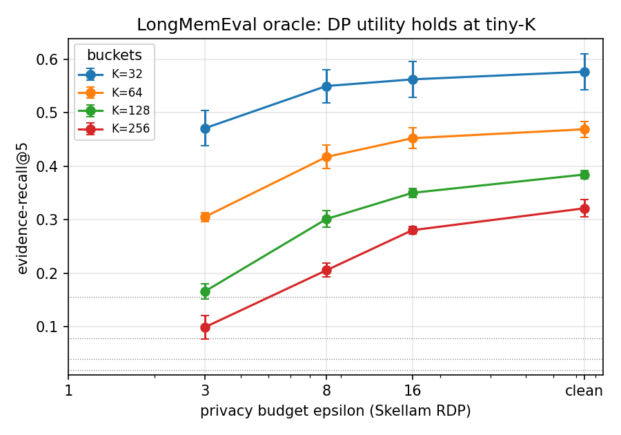

**Figure 1.** Retrieval utility vs privacy budget (LongMemEval oracle, d=32). At coarse `K=32` the private pool tracks the clean curve (95% retention at ε≈9.3) while higher-fidelity `K` starves buckets and DP noise bites. Dotted lines mark per-`K` chance. Error bars are 5-seed std.

### 7.2 The dimension/density crossover (real embeddings)

On **real `all-MiniLM-L6-v2`** embeddings (N=100, K=32), growing `d` **hurts both axes at once**:

| d | clean util | retention@ε≈9.3 | clean tail-AUC (leakage, K=1024) |
| --- | --- | --- | --- |
| **32** | 0.356 | **92%** | **0.944** |
| 64 | 0.359 | 87% | 0.969 |
| 128 | 0.358 | 78% | 0.985 |
| 384 | 0.318 | 62% | 0.990 |

Higher `d` means **more pre-DP leakage** (tail-AUC 0.94→0.99: high-d embeddings are more unique, hence more re-identifiable) **and less DP utility-retention** (92%→62%: more coordinates to noise). **Tiny-d is therefore Pareto-preferred**: the central design principle, and exactly the regime agent-memory payloads occupy.

**Tiny-`d` is a dual-benefit regulariser, not a trade-off dial.** It is worth stating the mechanism explicitly, because the two effects are usually discussed apart. Reducing `d` (i) *compresses the uniqueness of the payload* — fewer coordinates in which a note can be individually distinctive, hence lower **pre-DP** leakage, the red curve — and (ii) *shrinks the surface exposed to additive noise* — fewer coordinates each carrying an independent Skellam draw, hence higher **post-DP** retention, the blue curve. The same knob buys privacy twice and pays for it once. This is why the two curves in Figure 2 move *against* each other rather than trading off: there is no `d` at which giving up leakage buys retention.

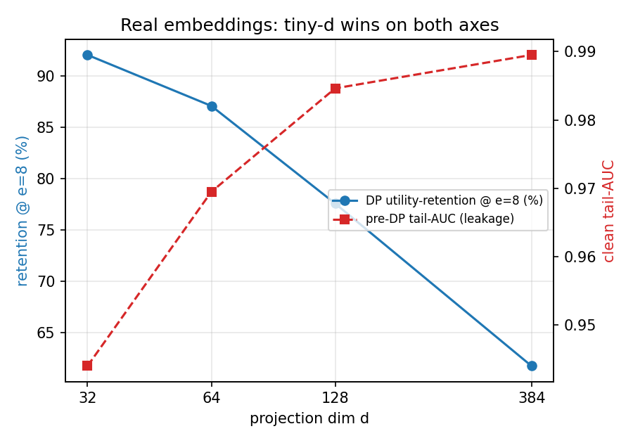

**Figure 2.** The dimension crossover on real `all-MiniLM-L6-v2` embeddings. Growing the projection dimension `d` simultaneously *raises* pre-DP leakage (red, right axis: clean tail-AUC 0.94→0.99) and *lowers* DP utility-retention (blue, left axis: 92%→62%). The two axes move against each other, so **tiny-`d` is Pareto-preferred**.

### 7.3 The leakage-drop endpoint (the positive result)

Membership inference on the **vulnerable low-count tail** collapses to chance under DP while bulk utility holds (LongMemEval oracle; MIA tail-AUC, 0.5 = no leakage):

| K | tail % | clean tail-AUC | ε≈9.3 tail-AUC | ε≈3.2 tail-AUC |
| --- | --- | --- | --- | --- |
| 512 | 1% | 0.873 | 0.578 | 0.567 |
| 1024 | 6% | **0.882** | **0.557** | 0.537 |
| 2048 | 17% | 0.872 | 0.526 | 0.520 |

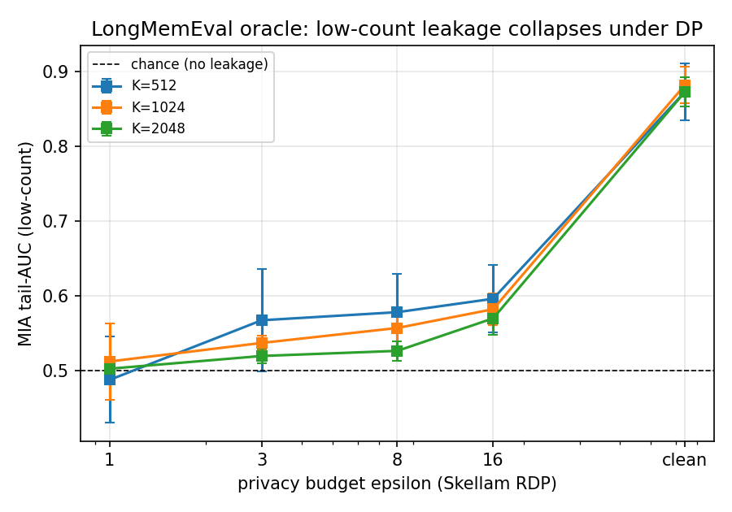

**Figure 3.** The leakage-drop endpoint (LongMemEval oracle). Membership-inference AUC on the vulnerable low-count tail (≤3 contributors) falls from ≈0.88 on the clean pool to chance (≈0.51, dashed line) under DP, uniformly across fidelity `K`: the positive, mechanism-grounded guarantee that generic federated-DP results lack.

### 7.4 Realistic payload: LLM-distilled notes

The real agent-memory payload (distilled notes) **strengthens** the case. The distillation is a fresh local-LLM run (Ollama `qwen2.5:7b`; 500 users → 6,116 notes, 100-user pilot → 1,715 notes), so absolute values differ slightly from any single earlier run but the ordering is unchanged.

**Utility** (answer-recall@5, vector-only release), density lifts DP retention:

| N (users) | K | clean | ε≈9.3 | retention |
| --- | --- | --- | --- | --- |
| **500** | 32 | 0.598 | **0.573** | **96%** |
| 500 | 64 | 0.508 | 0.457 | 90% |
| 100 (pilot) | 32 | 0.638 | 0.448 | 70% |

At full scale (500 users, denser buckets) the distilled pool retains **96% at ε≈9.3**; the 100-user pilot retains 70%; **density, not scale per se, governs retention** (more contributors per bucket ⇒ cheaper DP).

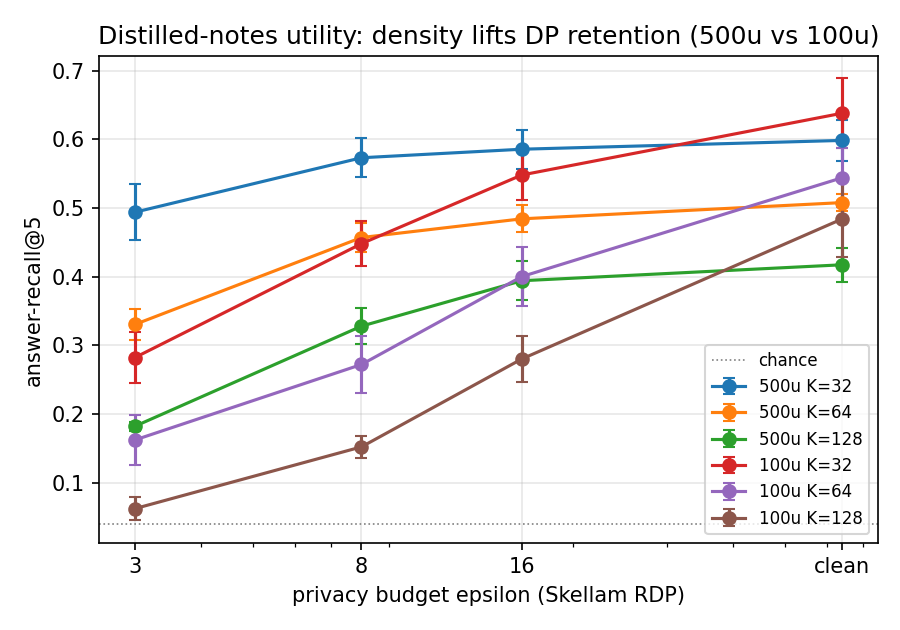

**Figure 4.** Distilled-notes utility (answer-recall@5). Density governs DP retention: the dense 500-user buckets (K=32) retain **96%** at ε≈9.3, whereas the sparser 100-user pilot retains only 70% at the same budget. More contributors per bucket ⇒ cheaper DP.

**Leakage**: distilled notes leak **more** than raw turns, yet DP kills both (full 500-user, K=1024, tail-AUC):

| source | clean all-AUC | clean tail-AUC | ε≈9.3 tail-AUC |
| --- | --- | --- | --- |
| raw dialogue turns | 0.638 | 0.895 | 0.572 |
| **LLM-distilled notes** | **0.726** | **0.925** | 0.553 |

Distillation **concentrates identifying facts**, so distilled memory is *more* re-identifiable pre-DP (all-AUC 0.64→0.73, tail 0.90→0.93), but the private release still drives both to ≈0.55 at ε≈9.3. The payload agents actually store is the one DP protects most decisively.

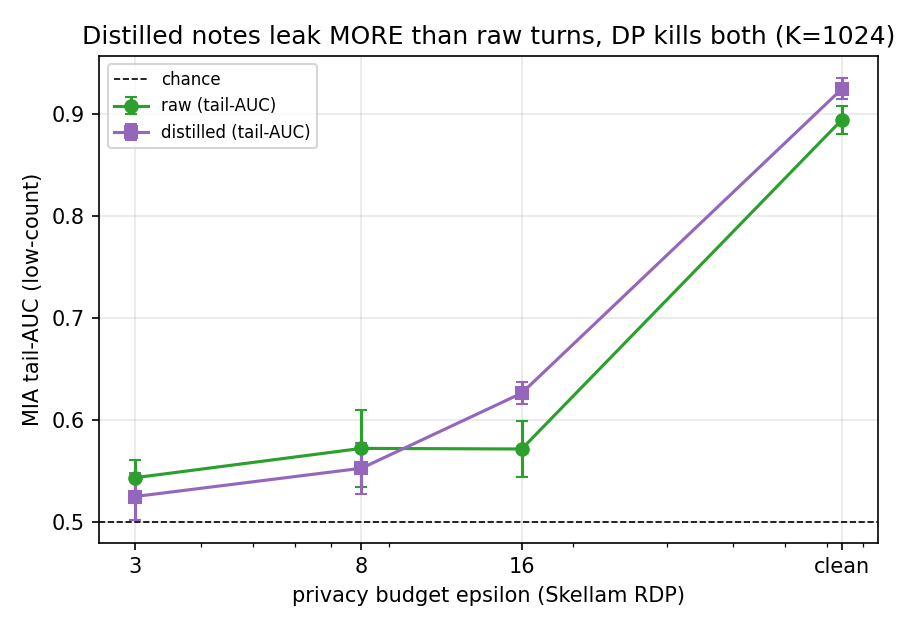

**Figure 5.** Distilled notes leak *more* than raw turns in the clear (distillation concentrates identifying facts: clean tail-AUC 0.90→0.93), yet the SecAgg+Skellam release collapses *both* to chance (≈0.55) at ε≈9.3. The realistic payload strengthens, not weakens, the result.

### 7.5 Accounting results

- **Discretisation is free.** At `range_max = 1e6` the discrete Skellam ε equals the Gaussian-RDP ε to 4+ decimals (surcharge < 1e-3); the integer/SecAgg quantisation costs no privacy.
- **Vector-only dominates, at a fixed occupancy rule.** At matched σ the vector-only release gives **identical recall to the last decimal** as the two-channel design, at **ε 13.9 → 9.3**, because the count *magnitude* only ever cancelled under normalisation. One composition, ~1.5× tighter ε, same utility. The one thing the count channel did supply is **occupancy** — which buckets are non-empty — and that does not cancel. At the `K` we recommend and report, no bucket is empty, so the rule is vacuous and the domination is unconditional; at high `K` an occupancy channel must be bought, and §7.10 measures what it costs and how well it works.

### 7.6 Robustness

Every number above is a **5-seed mean with the final (not peak) metric**. Re-running the full grid at 5 seeds reproduced the 2-seed exploration headlines with **no sign flip** (e.g. K=32 retention ≈95%; oracle tail-AUC 0.88→0.56 preserved), addressing the single-seed / peak-metric pitfalls that inflate DP-FL results.

### 7.7 At-scale generality (LongMemEval `s`, 246k notes)

We repeat the utility and leakage measurements on the **full `s` variant**, the same 500 users but **246,073 notes** (~96% distractors), ~22× the oracle corpus, the paper's at-scale generality check. Both axes behave exactly as §8's density argument predicts.

**Utility is nearly free** (evidence-recall@5, d=32, 5-seed):

| K | chance | clean | ε≈9.3 | ε≈3.2 | retention@ε≈9.3 |
| --- | --- | --- | --- | --- | --- |
| **32** | 0.156 | 0.525 | 0.523 | 0.527 | **99%** |
| 64 | 0.078 | 0.405 | 0.404 | 0.397 | **100%** |
| 128 | 0.039 | 0.320 | 0.313 | 0.304 | **98%** |
| 256 | 0.020 | 0.271 | 0.262 | 0.233 | **97%** |

**The vulnerable tail vanishes.** At this density essentially all 500 users contribute to every bucket, so the low-count tail (≤3 contributors) is **empty (0% of members)** across K ∈ {512, 1024, 2048}, and membership inference is **already at chance without DP** (all-AUC ≈ 0.50):

| K | low-count tail % | clean all-AUC | ε≈9.3 all-AUC |
| --- | --- | --- | --- |
| 512 | 0.0% | 0.499 | 0.500 |
| 1024 | 0.0% | 0.512 | 0.507 |
| 2048 | 0.0% | 0.511 | 0.502 |

This is the honest at-scale reading promised in §8: the dramatic leakage-*drop* is a sparse-tail phenomenon (§7.3), whereas the dense at-scale regime is **safe on both axes for free**: averaging over hundreds of contributors per bucket already destroys the membership signal, and DP costs almost no utility. The at-scale run therefore **confirms and bounds** the headline rather than extending it.

### 7.8 Calibrated attack: LiRA membership inference + extraction

The similarity scores in §7.2–7.4 embody the *measurement principle* of MEXTRA/MRMMIA but are a weak, uncalibrated proxy. We now run the **modern MIA standard** against the released pool: an **offline LiRA** (Carlini et al., S&P 2022) that, for each candidate note, estimates its membership-score distribution when it is *aggregated into* vs *held out of* the pool from many **shadow releases** (cheap here: our aggregation is numpy, not model training) and tests with the per-target likelihood ratio. We report **ROC-AUC and the low-FPR TPR** (the operationally meaningful metric that AUC-only proxies hide), plus a **reconstruction-decode extraction** attack (MEXTRA analog): decode each released centroid to its nearest note and score a hit when the top-1 decoded note is a true in-bucket member. Fits use a shadow split disjoint from the evaluation shadows (no train-on-test bias).

**The clean release is far more leaky than the proxy revealed, and DP still defeats the strong attack** (LongMemEval oracle, d=32, 3 seeds × 48 shadow releases):

| K | release | AUC | TPR@1%FPR | TPR@0.1%FPR | decode-extract |
| --- | --- | --- | --- | --- | --- |
| 1024 | clean | 0.994 | **0.898** | 0.778 | 0.854 |
| 1024 | ε≈9.3 | 0.534 | **0.011** | 0.001 | 0.078 |
| 1024 | ε≈3.2 | 0.505 | 0.011 | 0.001 | 0.018 |

| K | clean TPR@1%FPR | ε≈9.3 TPR@1%FPR | clean decode | ε≈9.3 decode |
| --- | --- | --- | --- | --- |
| 512 | 0.802 | 0.012 | 0.809 | 0.177 |
| 1024 | 0.898 | 0.011 | 0.854 | 0.078 |
| 2048 | 0.916 | 0.012 | 0.895 | 0.039 |

### 7.9 The published attacks against a live agent (MEXTRA / MRMMIA)

The attacks so far operate on the released embeddings. To close the loop on the *published* threat model (a live LLM agent that stores and serves memory as **text**), we build an A-MEM/Mem0-style shared-memory agent (local `qwen2.5:7b`) and run both attacks end-to-end. The agent retrieves the top-`k` shared-memory notes for a query into its context and answers; the adversary issues (a) a **MEXTRA** extraction prompt that asks the agent to reproduce its memory verbatim, and (b) a **MRMMIA** membership probe for a candidate note. We hold the distilled notes fixed and swap only the shared-memory back-end:

| shared memory back-end | MEXTRA verbatim-recovery | MRMMIA-AUC |
| --- | --- | --- |
| **raw text (baseline, no privacy)** | **1.000** | **0.938** |
| **our SecAgg+Skellam centroid pool (ε≈9.3)** | **0.000** | 0.454 |

(60 users, 883 distilled notes, K=256, d=32; 40 extraction and 120 membership trials.) On the raw-text agent both published attacks succeed decisively: every targeted member note is reproduced verbatim and membership is inferred at AUC 0.94. Against our release they collapse to **nothing**: the centroid pool contains **no note text**, so the extraction prompt has nothing to surface (the most an adversary can recover is a *public* note decoded from a centroid, §7.8) and the membership probe is at chance. The mechanism's role is thus concrete on the real payload: it does not merely lower an attack score, it **removes the very artifact the published attacks operate on**. (This is a demonstration at modest scale, not a tuned attack sweep; a stronger prompt-injection adversary against the raw baseline would only widen the gap, since our release exposes no text either way.)

### 7.10 Occupancy: what the count channel actually buys (§5.3)

An empty bucket is the one place the count channel is not redundant: `normalize` turns a pure-noise `S[k]` into a unit vector that competes for top-`k` slots against genuine centroids. We measure (a) how often empty buckets occur, and (b) whether they can be detected *privately*. Real LongMemEval-oracle (10,957 notes, 500 users, d=32), σ_v = 0.606 (ε≈9.28); occupancy over 5 anchor seeds, detection on a single release. Reproduce with `scripts/agentmem/_occupancy_channel.py`.

**(a) At the operating points, there are none.**

| K | 32 | 64 | 128 | 256 | 512 | 1024 | 2048 |
| --- | --- | --- | --- | --- | --- | --- | --- |
| empty buckets (%) | **0.00** | **0.00** | **0.00** | 0.08 ± 0.16 | 0.74 ± 0.62 | 6.54 ± 0.97 | 19.87 ± 0.63 |

Every retrieval number in this paper is reported at `K ≤ 256`, where at most **one bucket of 256** is ever empty; at the recommended `K = 32` there are none on any seed. The noisy-normalisation failure mode is **absent from the reported utility** rather than suppressed by tuning.

**(b) Where it does occur, occupancy is expensive to release.** Detection AUC (empty vs occupied; 0.5 = undetectable), against the total ε of the release:

| occupancy rule | ε | K=512 | K=1024 | K=2048 |
| --- | --- | --- | --- | --- |
| `‖S[k]‖` vs analytic noise floor `σ·C·√d` (free: post-processing) | **9.28** | 0.673 | 0.613 | 0.510 |
| noisy count channel, σ_c = 2 (cheap second composition) | 9.78 | 0.657 | 0.658 | 0.579 |
| noisy count channel, σ_c = σ_v (full second composition) | 13.93 | 0.848 | 0.801 | 0.698 |

Two readings, both load-bearing. First, under **user-level** DP the count channel is *not* the cheap sensitivity-1 object it is under note-level DP: a user contributes up to `n_u` notes, so its clipped count vector carries `C_c ≈ 12–20`, and paying a full second composition (ε 9.28 → 13.93) still leaves detection at AUC 0.70 exactly where it is most needed (`K = 2048`, 20% empty). Second, the free rule — thresholding the released vector's own norm against `σ·C·√d`, which costs no privacy because `S` is already public — degrades to chance (0.510) in that same regime.

Neither is an implementation shortfall. The DP noise that drives membership inference to chance in a one-contributor bucket (§7.3) is *the same noise* that hides whether the bucket has a contributor at all: **occupancy and membership are the same signal**, and a mechanism cannot hide the member while revealing the bucket. The design consequence is to operate at dense `K`, where retention is highest anyway (§7.1), rather than to buy a count channel that cannot pay for itself.

## 8. Discussion and Limitations

**Attack strength.** We evaluate at three escalating strengths and the endpoint holds at each: (i) an embedding-similarity proxy (§7.2–7.4); (ii) a **calibrated offline-LiRA** MIA reported at low-FPR TPR plus a reconstruction-decode extraction attack (§7.8), which reveal the clean pool is *more* leaky than the proxy showed (TPR@1%FPR ≈ 0.90, ≈85% note reconstruction), yet still fall to chance under DP; and (iii) the **published MEXTRA/MRMMIA attacks against a live agent** (§7.9), which fully extract a raw-text memory (recovery 1.0, AUC 0.94) but recover nothing from the centroid release. The endpoint thus **strengthens** as the attack gets stronger. Limits of (iii): it is a modest-scale demonstration on one open model with untuned extraction prompts; a stronger prompt-injection adversary would widen, not close, the gap, since our release exposes no text regardless. A user-level (rather than note-level) live-agent attack is left to future work.

**Scope.** Utility is retrieval fidelity of the pooled memory (bucket routing), not end-to-end downstream QA; extending to generated-answer quality is future work. Retrieval is bucket-granular, not exact-note ranking. `K`/`d`/clip bounds are set from data percentiles, not tuned per user.

**Deployment gaps we specify but do not measure.** Three, stated plainly. (i) **Client dropout:** our runs assume full participation. A naive $\mu/N$ noise share loses the guarantee precisely when turnout falls — at 50% survival the true budget is ε≈13.9, not the nominal 9.3 — so a deployment must use the $M_{\min}$-calibrated share or fault-tolerant noise reconstruction of §5.6. We specify both; we measure neither. (ii) **Occupancy at high `K`:** the released leakage code suppresses zero-count buckets using clean counts — a non-private oracle step. It is a no-op at every `K` where we report retrieval (§7.10a) and cannot affect members (a member's own note occupies its bucket); it does zero the centroid for the 1.2% / 3.6% of non-members that fall in an unpooled bucket at `K = 1024 / 2048`, the settings used only for the leakage tables of §7.3, shifting clean and private tail-AUC alike. §7.10b prices the private replacements, none of which is simultaneously free and accurate; the honest reading is that near-empty buckets cannot be *both* privately aggregated and privately enumerated. (iii) **δ at production scale:** δ = 10⁻⁵ is 200× below `1/N` at our `N = 500` **users**, but a 10⁵-user fleet must retighten it (§5.4), at a cost of < 23% ε.

**Non-novel components, explicitly.** The dimension dependence of DP is classical [19, 20]; we claim only its *coupled* manifestation across leakage and utility in agent memory. The SecAgg + Skellam path is prior work [2, 5, 6], and the LSH-bucketing-plus-DP skeleton overlaps the centralized *DP Datastore Generation* [15] (§2); the novelty is the federated/curator-free SecAgg+Skellam composition, the agent-memory payload, and the measured attack-drop endpoint.

## 9. Conclusion

Shared LLM-agent memory can be made **useful and provably private simultaneously**. By aggregating per-user bucketed memory embeddings under Secure Aggregation and the Skellam mechanism, the pooled memory carries a curator-free central-DP guarantee, retains **95–96% of clean retrieval utility at ε≈9.3** in the tiny-d / coarse-K regime agent payloads occupy, and drives worst-case membership inference on vulnerable members from **near-certain to chance**. The dimension/density crossover makes tiny-d a joint optimum (a regulariser that lowers pre-DP leakage and raises post-DP retention with one knob), the discrete mechanism is privacy-free at our resolution, a vector-only release dominates once bucket occupancy is accounted for, and, reassuringly, the realistic distilled payload, which leaks *more* in the clear, is protected *more* decisively by DP. Across three escalating attack strengths (an embedding proxy, a calibrated offline-LiRA with reconstruction-decode extraction, and the published MEXTRA/MRMMIA attacks against a live agent), the endpoint holds and in fact strengthens: the raw-text memory is fully extractable while our release exposes no note text at all. The at-scale run confirms the honest boundary of the headline rather than overturning it.

## 10. Reproducibility

Active code lives in **`scripts/agentmem/`** (see `scripts/README.md`); the pooled crypto is `qpriviot_fl/privacy_utils.py`.

- **Utility**: `_longmemeval_probe.py` (real), `_agentmem_probe.py` (controls), `_longmemeval_distilled_utility.py` (distilled).
- **Leakage (proxy)**: `_longmemeval_leakage.py`, `_agentmem_leakage.py`, `_longmemeval_distilled_analysis.py` (raw-vs-distilled).
- **Leakage (calibrated, §7.8)**: `_agentmem_lira.py`, offline-LiRA MIA (AUC + low-FPR TPR) and reconstruction-decode extraction, via shadow releases.
- **Leakage (live agent, §7.9)**: `_agentmem_llm_attack.py`, an A-MEM/Mem0-style shared-memory agent (local Ollama) under end-to-end MEXTRA extraction + MRMMIA membership prompts, contrasting a raw-text memory vs our centroid release.
- **Accounting**: `_skellam_accounting.py` (Skellam-RDP ε; discretisation-free check).
- **Distillation**: `_longmemeval_distill.py` turns LongMemEval turns into A-MEM/Mem0-style notes via a local Ollama model (`qwen2.5:7b`); it checkpoints incrementally.
- **Drivers → tables/figures**: `scripts/shell/rerun_grid.sh` runs the 33-config, 5-seed grid into `experiment_results/rerun_grid/*.json`; `scripts/shell/rerun_svariant.sh` runs the at-scale `s`-variant (§7.7) into `experiment_results/rerun_grid_s/*.json`; `scripts/shell/rerun_lira.sh` runs the calibrated-attack grid (§7.8) into `experiment_results/lira/*.json`; `rerun_tables.py` and `rerun_figures.py` regenerate `SUMMARY_TABLE.md` and `figures/fig_*`. Each script has an additive `--json` dump; the crypto path is byte-identical to the released `privacy_utils`.

Run: `bash scripts/shell/rerun_grid.sh && python scripts/agentmem/rerun_tables.py && python scripts/agentmem/rerun_figures.py` (and `bash scripts/shell/rerun_svariant.sh` for §7.7, `bash scripts/shell/rerun_lira.sh` for §7.8; §7.9 needs a local `ollama serve` with `qwen2.5:7b`).

## References

*Note: the 2025–2026 agent-memory arXiv identifiers below were verified against the live arXiv/venue record (2026-07); titles and attributions match the published metadata.*

[1] McMahan et al. *Communication-Efficient Learning of Deep Networks from Decentralized Data.* AISTATS 2017. [2] Bonawitz et al. *Practical Secure Aggregation for Privacy-Preserving Machine Learning.* CCS 2017. [3] Abadi et al. *Deep Learning with Differential Privacy.* CCS 2016. [4] Mironov. *Rényi Differential Privacy.* CSF 2017. [5] Agarwal, Kairouz, Liu. *The Skellam Mechanism for Differentially Private Federated Learning.* NeurIPS 2021 (arXiv:2110.04995). [6] Kairouz et al. *The Distributed Discrete Gaussian Mechanism for Federated Learning with Secure Aggregation.* ICML 2021. [7] Reimers, Gurevych. *Sentence-BERT.* EMNLP 2019 (all-MiniLM-L6-v2). [8] Wu et al. *LongMemEval: Benchmarking Chat Assistants on Long-Term Interactive Memory.* 2024. [9] Xu et al. *A-MEM: Agentic Memory for LLM Agents.* 2024. [10] Chhikara et al. *Mem0: Building Production-Ready AI Agents with Scalable Long-Term Memory.* 2024. [11] Wang et al. *Unveiling Privacy Risks in LLM Agent Memory.* ACL 2025 (arXiv:2502.13172); introduces the **MEXTRA** memory-extraction attack. [12] Chen, Pang, Wang. *MRMMIA: Membership Inference Attacks on Memory in Chat Agents.* arXiv:2605.27825. [13] Rezazadeh et al. *Collaborative Memory: Multi-User Memory Sharing in LLM Agents with Dynamic Access Control.* arXiv:2505.18279. [14] Chen et al. *MemPrivacy: Privacy-Preserving Personalized Memory Management for Edge-Cloud Agents.* arXiv:2605.09530. [15] Abouelenein, Torki. *Differentially Private Datastore Generation for Retrieval-Augmented Inference.* arXiv:2606.01413. [16] Hou et al. *POPri: Private Federated Learning using Preference-Optimized Synthetic Data.* arXiv:2504.16438. [17] Chen et al. *Fed-SE: Federated Self-Evolution for Privacy-Constrained Multi-Environment LLM Agents.* arXiv:2512.08870. [18] Lin et al. *A Survey on the Security of Long-Term Memory in LLM Agents.* arXiv:2604.16548. [19] Chen et al. *The Effect of Dimensionality on Differentially Private Deep Learning.* ICML 2022 (arXiv:2203.03761). [20] Bassily, Smith, Thakurta. *Private Empirical Risk Minimization.* FOCS 2014.